# Human Activity Prediction Model - Assignment for Practical Machine Learning Course

Sampath Kumar Padmanaban

April 25, 2015

# Objective

Using devices such as Jawbone Up, Nike FuelBand, and Fitbit it is now possible to collect a large amount of data about personal activity relatively inexpensively. These type of devices are part of the quantified self movement – a group of enthusiasts who take measurements about themselves regularly to improve their health, to find patterns in their behavior, or because they are tech geeks. One thing that people regularly do is quantify how much of a particular activity they do, but they rarely quantify how well they do it.

The objective of this project, is to use data from accelerometers on the belt, forearm, arm, and dumbell of 6 participants. They were asked to perform barbell lifts correctly and incorrectly in 5 different ways. The goal of this project is to predict the manner in which they did the exercise. This is the “classe” variable in the training set. The pediction model will also be used to predict 20 different test cases.

# Initial Setup

```r
library(caret)
```

```r
library(corrplot)
library(kernlab)
library(knitr)
library(randomForest)
```

# Loading and processing data

The training data for this project are available here: https://d396qusza40orc.cloudfront.net/predmachlearn/pml-training.csv

The test data are available here: https://d396qusza40orc.cloudfront.net/predmachlearn/pml-testing.csv

The data for this project come from this source: http://groupware.les.inf.puc-rio.br/har.

```r
# Create a working directory for processing these files
if (!file.exists("data")) {dir.create("data")}

# Create file URLs and destination file
urlTrain <- "https://d396qusza40orc.cloudfront.net/predmachlearn/pml-training.csv"
fileTrain <- "./data/pml-training.csv"
urlTest <- "https://d396qusza40orc.cloudfront.net/predmachlearn/pml-testing.csv"
fileTest <- "./data/pml-testing.csv"

# download the file and note the time (method='curl' is needed only for Mac Os)
download.file(urlTrain, destfile = fileTrain, method='curl')
download.file(urlTest, destfile = fileTest, method='curl')
```

## Loading the Training Data

```r
# Load the training data from the csv file
trainData <- read.csv("./data/pml-training.csv", na.strings= c("NA",""," "))

# remove the columns with NA values
train_NAs <- apply(trainData, 2, function(x) {sum(is.na(x))})
trainData <- trainData[,which(train_NAs == 0)]

# remove identifier columns such as name, timestamps etc
trainData <- trainData[8:length(trainData)]
```

## Loading the Test Data

```r
# Load the test data from the csv file
testData <- read.csv("./data/pml-testing.csv", na.strings= c("NA",""," "))
test_NAs <- apply(testData, 2, function(x) {sum(is.na(x))})
testData <- testData[,which(test_NAs == 0)]
testData <- testData[8:length(testData)]
```

# Model for prediction

A Random Forest Model approach was selected for predicting the ‘classe’ variable. A random forest model is best suited in this case because this model has methods for balancing error in class population of unbalanced data sets.

## Data for Training and Cross Validation

The training data is first split into two part - training and cross validation. The data is split into 70:30 ratio.

```r
# split the training data into training and cross validation
splitTrain <- createDataPartition(y = trainData$classe, p = 0.7, list = FALSE)
forTraining <- trainData[splitTrain, ]
forCrossValidation <- trainData[-splitTrain, ]
```

## Correlation of variables

Before preparing the Random Forest prediction model, it is essential to check the level of correlation between the variables as this will increase the forest error rate.

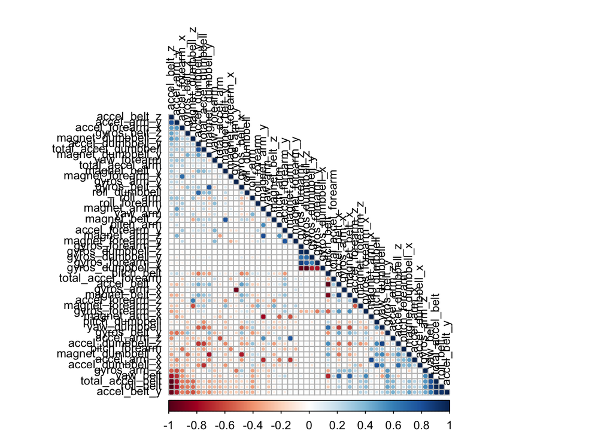

```r
# plot a correlation matrix
correlation <- cor(forTraining[, -length(forTraining)])
corrplot(correlation, order = "FPC", method = "circle", type = "lower", tl.cex = 0.8,  tl.col = rgb(0, 0, 0))
```

## Random Forest Model

A Random Forest model is prepared with all the variables to predict the classification. The training data set is used for this model.

```r
trainRFModel <- randomForest(classe ~ ., data = forTraining)
trainRFModel
```

```
##
## Call:
##  randomForest(formula = classe ~ ., data = forTraining)
##                Type of random forest: classification
##                      Number of trees: 500
## No. of variables tried at each split: 7
##
##         OOB estimate of  error rate: 0.56%
## Confusion matrix:
##      A    B    C    D    E  class.error
## A 3905    1    0    0    0 0.0002560164
## B   12 2637    9    0    0 0.0079006772
## C    0   18 2374    4    0 0.0091819699
## D    0    0   26 2225    1 0.0119893428
## E    0    0    1    5 2519 0.0023762376
```

The OOB Error from this model is very low. It is only 0.56%. This is good enough to proceed further with cross validation.

## Cross validation of the model

```r
# crossvalidate the model
predictCrossVal <- predict(trainRFModel, forCrossValidation)
confusionMatrix(forCrossValidation$classe, predictCrossVal)
```

```
## Confusion Matrix and Statistics
##
##           Reference
## Prediction    A    B    C    D    E
##          A 1674    0    0    0    0
##          B    6 1126    7    0    0
##          C    0   10 1016    0    0
##          D    0    0   12  951    1
##          E    0    0    0    2 1080
##
## Overall Statistics
##
##                Accuracy : 0.9935
##                  95% CI : (0.9911, 0.9954)
##     No Information Rate : 0.2855
##     P-Value [Acc > NIR] : < 2.2e-16
##
##                   Kappa : 0.9918
##  Mcnemar's Test P-Value : NA
##
## Statistics by Class:
##
##                      Class: A Class: B Class: C Class: D Class: E
## Sensitivity            0.9964   0.9912   0.9816   0.9979   0.9991
## Specificity            1.0000   0.9973   0.9979   0.9974   0.9996
## Pos Pred Value         1.0000   0.9886   0.9903   0.9865   0.9982
## Neg Pred Value         0.9986   0.9979   0.9961   0.9996   0.9998
## Prevalence             0.2855   0.1930   0.1759   0.1619   0.1837
## Detection Rate         0.2845   0.1913   0.1726   0.1616   0.1835
## Detection Prevalence   0.2845   0.1935   0.1743   0.1638   0.1839
## Balanced Accuracy      0.9982   0.9942   0.9898   0.9976   0.9993
```

The accuracy from this model is almost 99.5% which is very good.

## Prediction with Test Data

The cleaned test data prepared earlier is used to test the model prepared above.

```r
# predict the classes of the test set
predictTest <- predict(trainRFModel, testData)
predictTest
```

```
##  1  2  3  4  5  6  7  8  9 10 11 12 13 14 15 16 17 18 19 20
##  B  A  B  A  A  E  D  B  A  A  B  C  B  A  E  E  A  B  B  B
## Levels: A B C D E
```

# Conclusion

A Random Forest model is used to ‘classe’ variable. The model has a low OOB Error of 0.56%. The model cross validated well with an accuracy of 99.5% and used to predict the test data set. Since the training data has a large number of observations, the model fits well to predict.